# Descrição Noticias

Allan Sales

22 de junho de 2017

# Bases de dados

## Sumário dos dados

Este documento apresenta uma descrição da coleta de notícias nos cadernos de política dos portais G1, Estadão e Folha de São Paulo. De cada notícia foram coletadas informaçãoes sobre data de publicação (timestamp), fonte (subFonte), título, subtítulo, conteúdo, emissor, url e número de comentários na notícia (repercussão). Outras informações contidas na base foram adicionadas manualmente ou são derivadas das originais. Do total de notícias coletados, 51246 são provenientes do jornal Estadão, 68748 são provenientes da Folha de São Paulo e 22804 são do G1.

```
##    timestamp                     subFonte            titulo
##  Min.   :2010-07-01 00:00:00   Length:142798      Length:142798
##  1st Qu.:2012-02-25 10:05:15   Class :character   Class :character
##  Median :2013-10-03 00:00:00   Mode  :character   Mode  :character
##  Mean   :2013-10-18 21:07:30
##  3rd Qu.:2015-07-08 19:54:45
##  Max.   :2017-05-24 22:54:00
##
##   subTitulo           conteudo           emissor
##  Length:142798      Length:142798      Length:142798
##  Class :character   Class :character   Class :character
##  Mode  :character   Mode  :character   Mode  :character
##
##
##
##
##      url             repercussao       idNoticia
##  Length:142798      Min.   :   0.00   Length:142798
##  Class :character   1st Qu.:   0.00   Class :character
##  Mode  :character   Median :   1.00   Mode  :character
##                     Mean   :  37.67
##                     3rd Qu.:  14.00
##                     Max.   :8126.00
##
##       data                 ano            mes             dia
##  Min.   :2010-06-30   Min.   :2010   Oct    :16958   Min.   : 1.0
##  1st Qu.:2012-02-25   1st Qu.:2012   Aug    :14379   1st Qu.: 8.0
##  Median :2013-10-02   Median :2013   Sep    :14068   Median :15.0
##  Mean   :2013-10-18   Mean   :2013   Mar    :12682   Mean   :15.6
##  3rd Qu.:2015-07-08   3rd Qu.:2015   May    :12088   3rd Qu.:23.0
##  Max.   :2017-05-24   Max.   :2017   Apr    :11768   Max.   :31.0
##                                      (Other):60855
##    dia_do_ano    is_ano_eleicao    n_palavras
##  Min.   :  1.0   Mode :logical   Min.   :    1.0
##  1st Qu.:104.0   FALSE:63116     1st Qu.:  246.0
##  Median :200.0   TRUE :79682     Median :  372.0
##  Mean   :191.7   NA's :0         Mean   :  430.5
##  3rd Qu.:277.0                   3rd Qu.:  533.0
##  Max.   :366.0                   Max.   :24971.0
##
```

### Exemplo de notícia

Notícia com 8126 comentários:

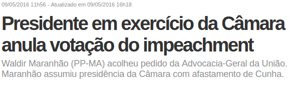

## Distribuição do número de comentários por portal

É possível visualizar ainda a partir do sumário que diversas são as notícias que não são comentadas. De fato, pelo menos 50% das notícias de toda a base apresentam até 1 comentário(s). Considerando apenas as notícias comentadas, podemos visualizar a distribuição da repercurssão para cada portal de notícias da seguinte forma:

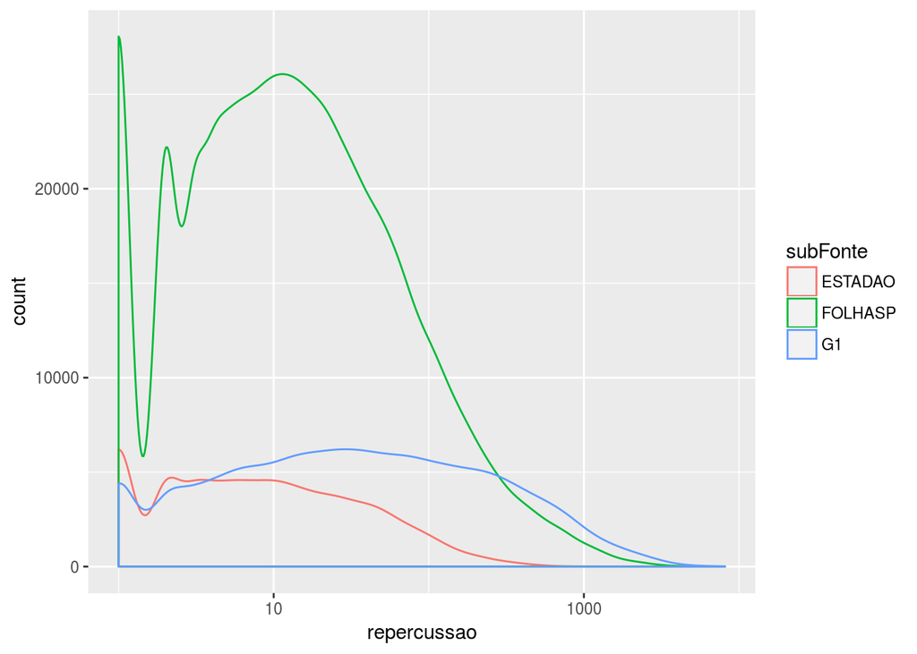

## Distribuição do número de palavras por portal

Além dos comentários, também é possível visualizar a distribuição do número de palavras de cada notícia. Isso é importante pode ser utilizado para se medir o detalhamento que o portal dá a sua notícias. Por exemplo, inferir se para notícias do assunto X o portal costuma fazer notícias resumidas enquanto para notícias do assunto Y as notícias são mais detalhadas.

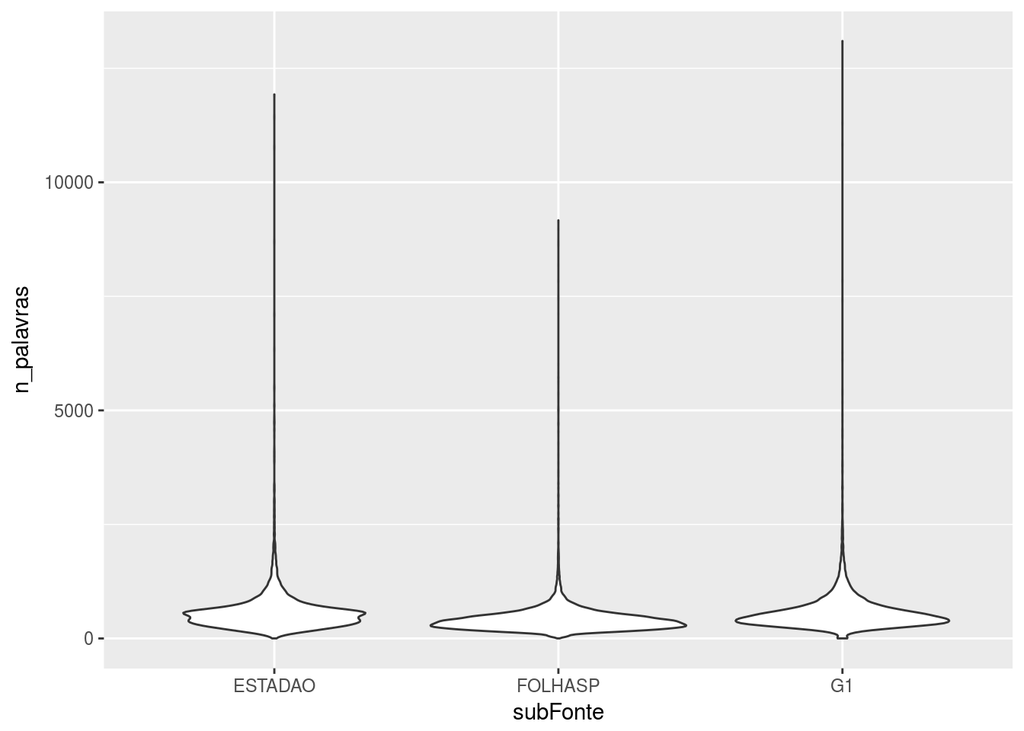

## Número de notícias por ano

Total de notícias por ano apresentada na base de dados.

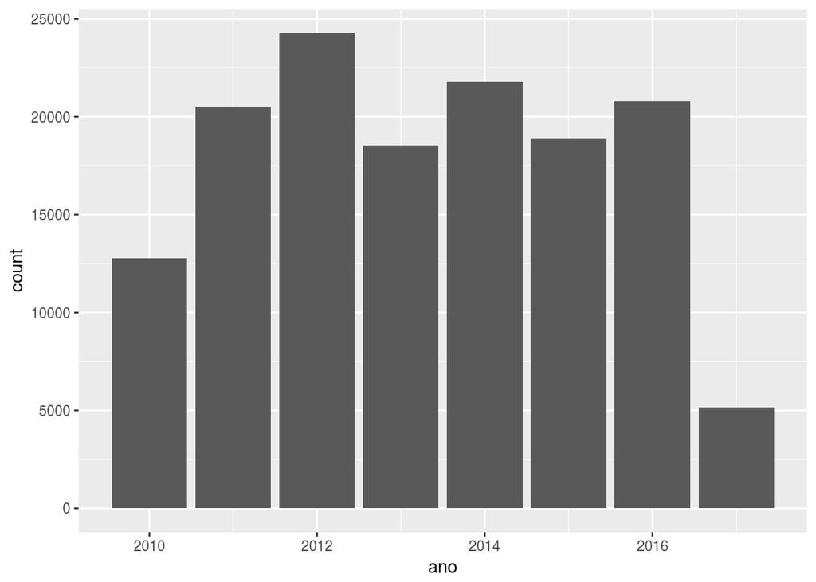

## Número de notícias por portal

### Distribuição de notícias por ano

Total de notícias por ano e separadas por portal na base de dados. É possível notar-se, a partir desse gráfico que as notícias coletadas no site do G1 ainda precisam ser colhidas novamente. O ano de 2010, 2014 e 2017 indicam o problema.

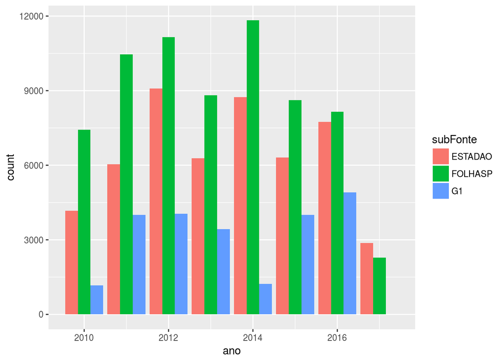

### Densidade de noticias por dia

Assim como o gráfico de barras anterior, o gráfico de densidade reforça a indicação de problemas na base do G1. Além disso, é possível visualizar uma tendência dos portais Estadão e Folha de São Paulo em publicar notícias de forma similar. Em períodos semelhantes as duas linhas crescem ou decrescem de forma similar. O que nos leva a pensar que pode existir uma correlação entre os portais.

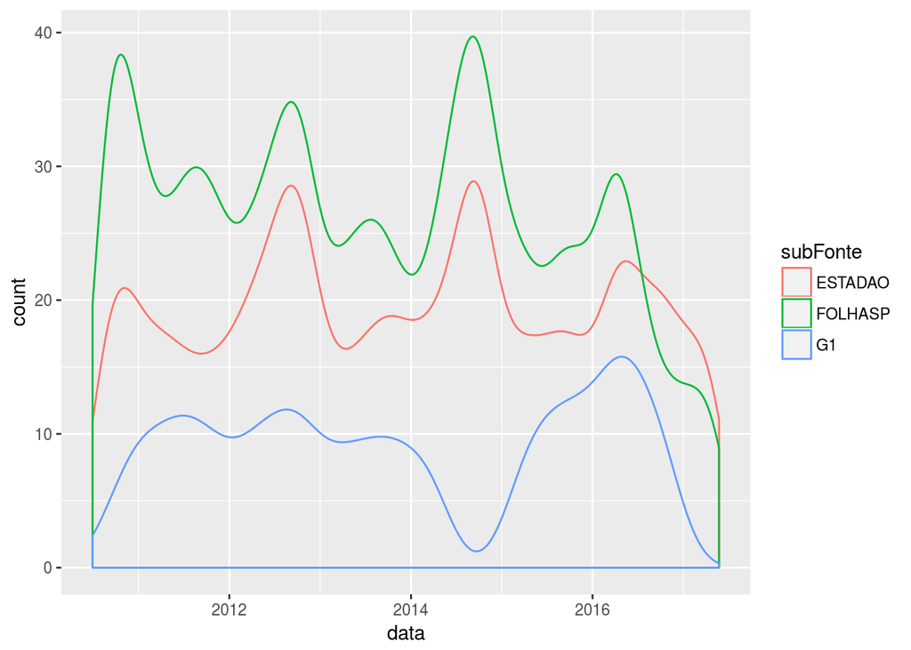

### Correlações de quantidades de notícias por portais

Os valores de correlação entre os portais são apresentados na tabela a seguir. Nota-se que, como especulado anteriormente, os portais Folha de São Paulo e Estadão apresentam um valor de correlação considerado alto, mas a surpresa dá-se pela relação entre G1 e Folha. Mesmo com problemas na coleta, a correlação entre esses dois portais que resultou no maior valor obtido.

```
## # A tibble: 3 x 4
##   rowname   ESTADAO   FOLHASP        G1
##     <chr>     <dbl>     <dbl>     <dbl>
## 1 ESTADAO        NA 0.3877959 0.2027205
## 2 FOLHASP 0.3877959        NA 0.4560698
## 3      G1 0.2027205 0.4560698        NA
```

## Média de publicação de notícias por mês

### Para todos os anos

Uma forma de visualizar a quantidade de notícias que cada portal publica por mês é utilizando a média juntamente ao desvio padrão. Abaixo aprensenta-se um gráfico com média e um intervalo de um desvio padrão para cima e para baixo, para cada portal. Nota-se que o portal G1 publica uma quantidade média de notícias relativamente parecidas durante todo o ano. Por outro lado, para o Estadao e para a Folha, as notícias tendem a ser publicadas com mais frequências nos meses que antecedem eleições. Todavia, o desvio padrão aumenta consideravelmente nesses meses, o que nos dá a entender que a média de publicação naqueles meses deve cair em anos que não há eleição.

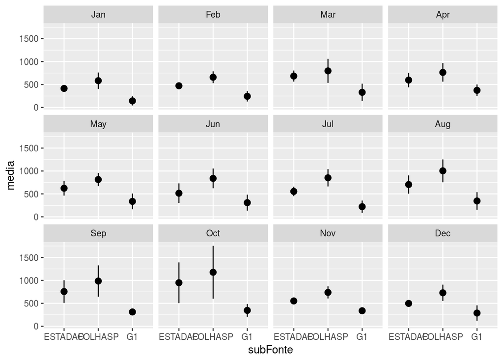

### Separando anos de eleição e anos sem eleição

Para saber se há diferença de publicação nos anos de eleição e nos anos de eleição, pode-se utilizar o intervalo de confiança de publicações nesses meses. Na figura abaixo, percebe-se que há sim o aumento de na média de publicações nos jornais Estadão e Folha de São Paulo. A medida que outubro vai se aproximando, a quantidade de publicações tende a crescer. No mês de outubro e setembro a distância é visualmente grande. Apesar disso, ainda é necessário aplicar o teste t para validar a informação de que há diferença estatística significante entre elas.

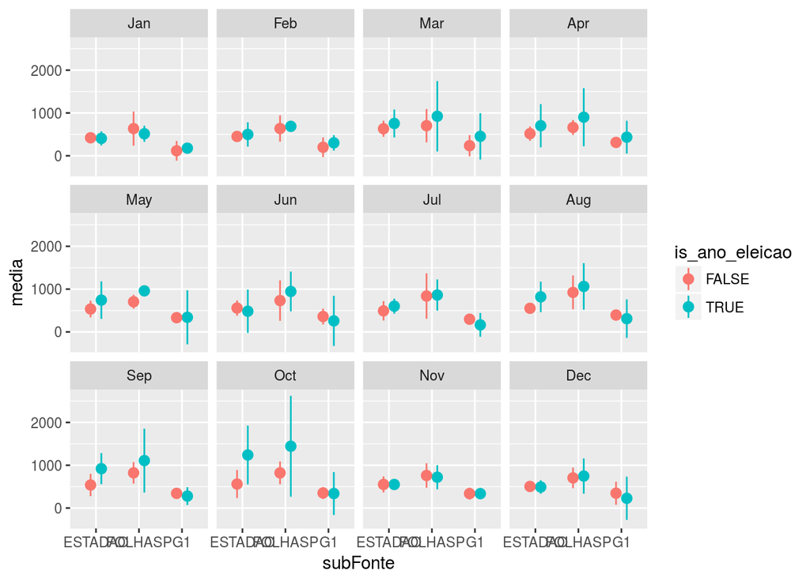

# Viés

O objetivo principal da pesquisa é encontrar e quantificar viés nas notícias. Viés pode ser definido como tudo que não for equilibrado. A inclinação política de um portal a um candidato, partido ou idéia são exemplos de viéses relacionados à política.

## Escolha das palavras

Uma forma simples de verificar a presença de viés é verificando as palavras mais frequêntes de cada texto. Nesse exemplo, faremos isso para a Folha de São Paulo e para o Estadão, tanto para os títulos das matérias quanto para o seu conteúdo.

### Jornal Estadão

#### Título

Wordcloud de termos mais utilizados nos títulos do jornal Estadão. Algumas palavras para se destacar: diz, impeachment, nega, cpi, mil.

[interactive chart not shown]

#### Conteúdo

Wordcloud de termos mais utilizados nos conteúdos do jornal Estadão.

[interactive chart not shown]

### Jornal Folha de São Paulo

#### Título

Wordcloud de termos mais utilizados nos títulos do jornal Folha de São Paulo. Algumas palavras para se destacar: diz, cpi, nega, mil.

[interactive chart not shown]

#### Conteúdo

Wordcloud de termos mais utilizados nos conteúdos do jornal Folha de São Paulo.

[interactive chart not shown]

## Escolha de que notícias publicar

Outra forma de viés é intrísseca do próprio jornalista. É a tomada de decisão sobre se a notícia vale a pena de ser publicada ou não. Como exemplo desse tipo de viés, mostramos alguns números a respeito de operações realizadas pela polícia federal e quanto de atenção cada operação teve dos veículos.

As operações utilizadas são:

- Operação Boca Livre: Fraude na Lei Rouanet - lei que institui políticas públicas para a cultura nacional;
- Operação Bullish: irregularidades em empréstimos do BNDES ao Frigorífico JBS;
- Operação Carne Fraca: grandes frigoríficos comercializavam e exportavam carnes vencidas mantidas com ácido sórbico e ácido ascórbico e pagamentos de propinas à fiscais do Ministério da Agricultura;
- Operação Perfídia: lavagem internacional de dinheiro por agências de turismo, casas lotéricas e postos de gasolina;
- Operação Zelotes: investigar um esquema de corrupção no Conselho de Administração de Recursos Fiscais (Carf), órgão colegiado do Ministério da Fazenda, responsável por julgar os recursos administrativos de autuações contra empresas e pessoas físicas por sonegação fiscal e previdenciária.

### Quantidade de notícias - título

Buscando pelo nome da operação nos títulos das matérias em cada jornal obtemos:

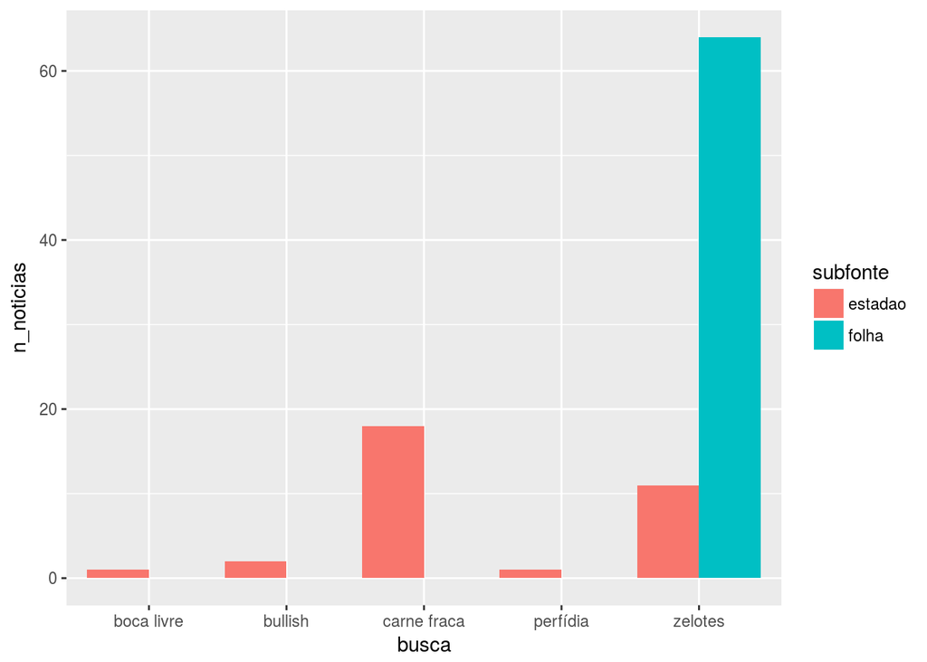

### Quantidade de notícias - conteúdo

Sabendo que não necessariamente uma matéria precisa apresentar o nome da operação no seu título, extendemos a busca também para o conteúdo das notícias. A figura apresenta o número de vezes que a operação é mencionada em suas matérias. Casos em que o nome da operação aparece mais de uma vez na mesma matéria não foram tratados.

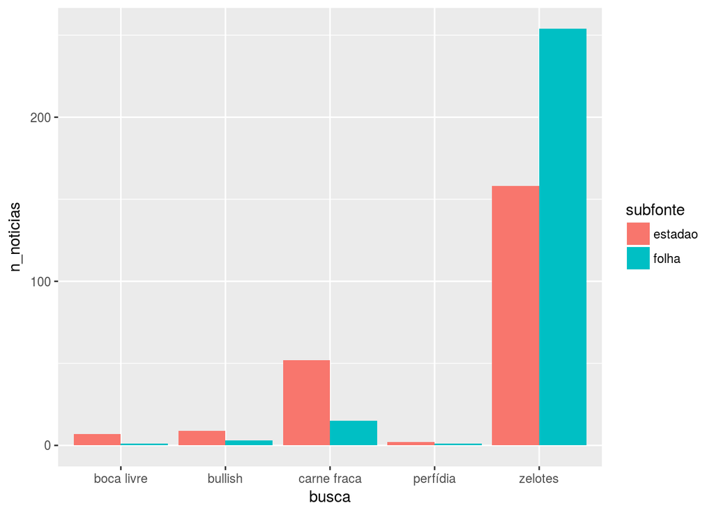

### Quantidade de notícias x lava jato - título

Para fins de comparação com a lava jato.

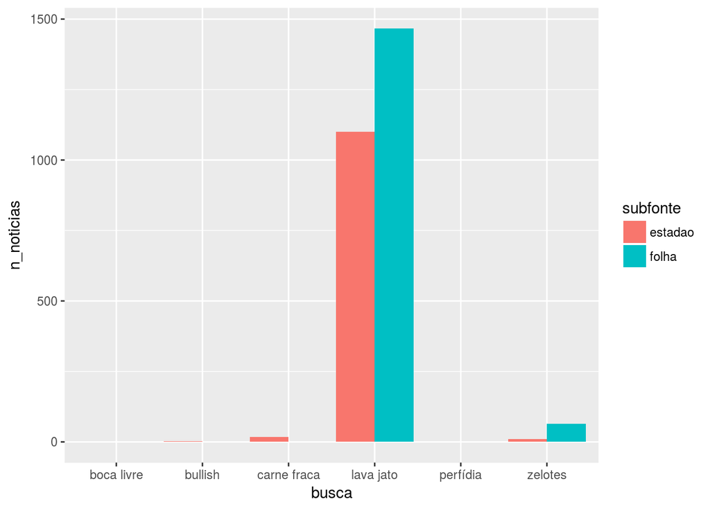

### Quantidade de notícias x lava jato - conteúdo

Para fins de comparação com a lava jato.

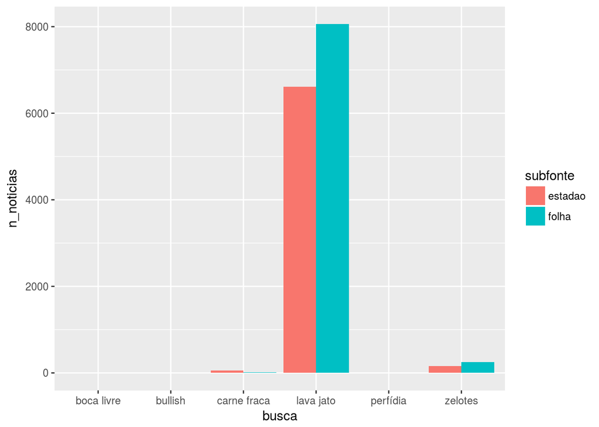

## Inclinação partidária ou a um político

Teoricamente toda notícia publicada é imparcial mas é quase impossível realmente mostrar imparcialidade em todas as notícias. Para iniciar a verificação da inclinação política partidária ou pessoal de cada jornal, utilizamos a eleição de 2014 como parâmetro. O período das notícias vai de 6 de julho de 2014 a 6 de outubro de 2014, dia da votação do primeiro turno.

### Número de notícias sobre cada candidato

De forma similar ao que já foi apresentado, pode-se verificar quantas notícias foram publicadas sobre cada um dos candidatos. Percebe-se que Dilma era mais citada na Folha de São Paulo do que qualquer outro político, mas sendo acompanhada de perto por Marina e com uma larga vantagem para Aécio e os outros candidatos. Até mesmo Lula, que não era candidato nessa eleição, tinha mais matérias sendo citado do que alguns dos candidatos.

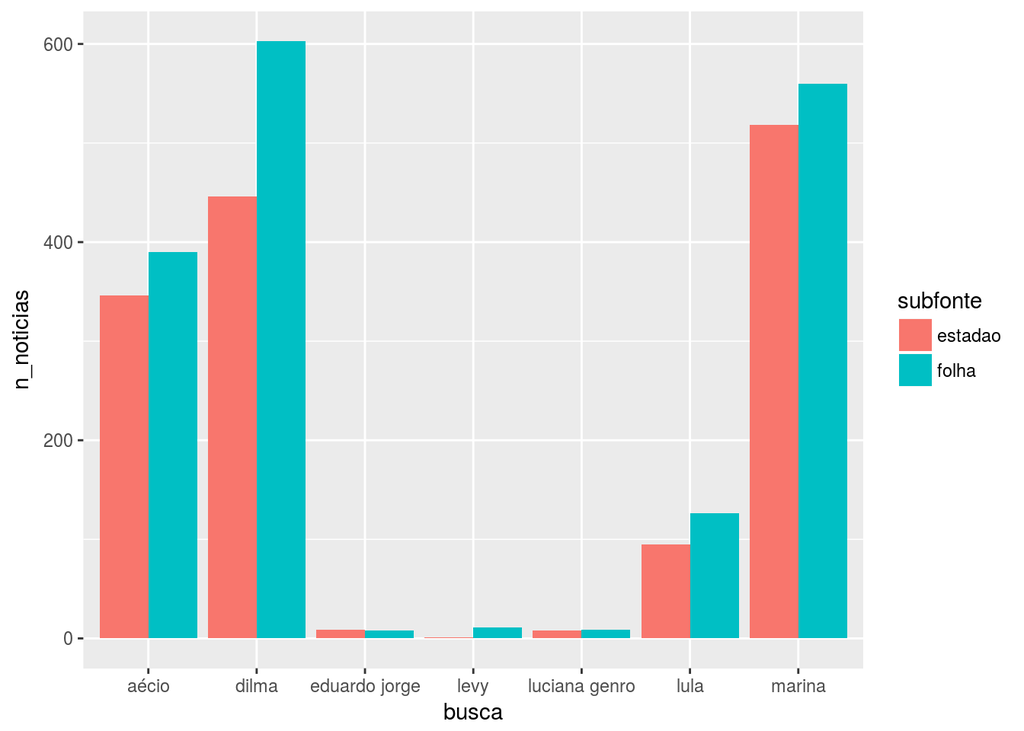

### Média de palavras por notícia

Pode-se questionar que mesmo que a quantidade de notícias seja a mesma, a discussão sobre aquele candidato não seja detalhada. Sendo assim, pode-se medir a quantidade média de palavras que eram escritas nos artigos falando de cada candidato. Nesse caso, nota-se que não há uma grande diferença de uns para os outros.

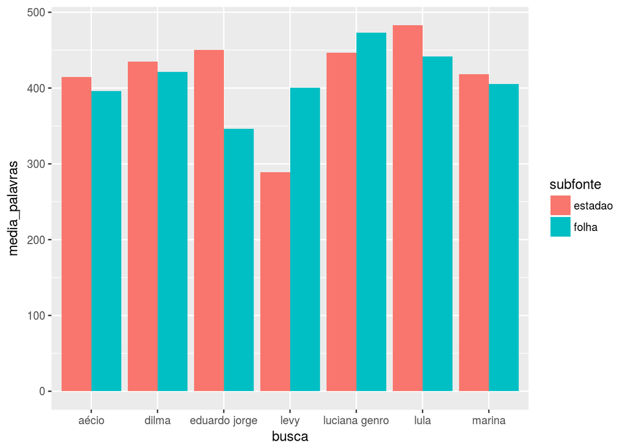